# 12 Intro to RMarkdown 2

Alyssa

2021-03-03

Week 6b  
Intro to RMarkdown 2

# Outline of class:

Working with RMarkdown today:  
1. Working with figures  
2. Working with tables  
3. Themes  
4. Advanced outputs

Lab:  
1. Practice with RMarkdown

# Libraries

```r
library(palmerpenguins)
library(tidyverse)
library(here)
library(kableExtra)
```

# 1. Working with Figures

aspects of the figure right in our markdown document:  
* change size  
* change resolution  
* change “device” (i.e. is it a .png. .pdf, etc.)  
* save it in a specific folder

```r
penguinsPlot <- penguins %>%
  ggplot(aes(x=species, y=flipper_length_mm, color=island)) +
  geom_boxplot() +
  theme_bw()
penguinsPlot
```

[output not shown]

## a. Change size

Some options:

- out.width=“70%” (makes it 70% of the width)
- fig.width=3 (makes the width 3 inches)
- fig.height=4 (makes the width 4 inches)
- fig.asp=1.2 (changes the aspect ratio to 1.2)
- fig.align=“center”
- We will walk through each of these examples together

[helpful tips](https://r4ds.had.co.nz/graphics-for-communication.html#figure-sizing)

{r, fig.align=‘center’, fig.asp=1.2}

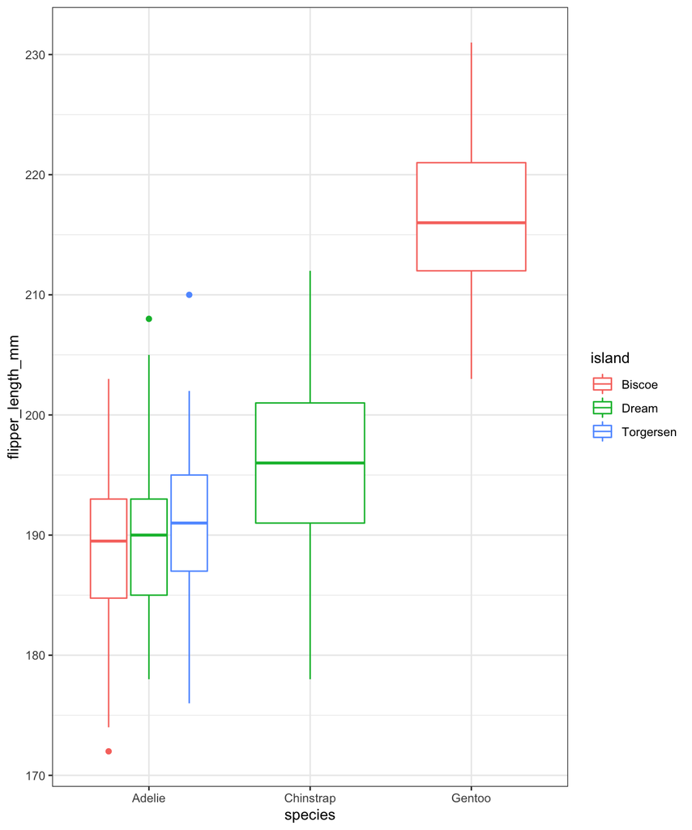

## b. Save your figure

ggsave or more automated ways to export your figures in rmarkdown

set the file path for your figure using:

- fig.path (you can put this in a global option to send all your figures there)
- name your code chunk (this will be the name of the figure)

Place between curly braces

- {r label}

Separated options with commas

- {r label, option1=value}

Set a figure caption

- fig.cap="This is a boxplot of penguins

If you just want the plot and not the code then set echo=FALSE

### label code chunks

label is inserted after the r and a space  
{r PenguinFig}

### fig.path

add this to chunk header  
fig.path=“../Outputs/”

the name given in the header will be used to name the file  
this can also be added to the global options in the setup

# 2. Tables

## a. type tables by hand

| Time | Session | Topic |
| --- | --- | --- |
| 01:00 | 1 | Anatomy |
| 01:50 |  | *Break* |
| 02:00 | 2 | Tables |
| 02:45 |  | *Break* |

## b. alignment

these line here, gives the alignment  
|:——|:——-:|———:|  
| *left* | *center*| *right* |  
the alignment is given by the poition of the :

## c. kable

install.packages(“kableExtra”) library(kableExtra)

make a kable table

```r
penguins %>%
  group_by(species) %>%
  summarise(billmean = mean(bill_length_mm, na.rm = TRUE)) %>%
  kbl()
```

| species | billmean |
| --- | --- |
| Adelie | 38.79139 |
| Chinstrap | 48.83382 |
| Gentoo | 47.50488 |

### themes like alterations

```r
penguins %>%
  group_by(species) %>%
  summarise(billmean = mean(bill_length_mm, na.rm = TRUE)) %>%
  kbl() %>%
  kable_classic()
```

| species | billmean |
| --- | --- |
| Adelie | 38.79139 |
| Chinstrap | 48.83382 |
| Gentoo | 47.50488 |

### row specific changes

```r
penguins %>%
  group_by(species) %>%
  summarise(billmean = mean(bill_length_mm, na.rm = TRUE)) %>%
  kbl() %>%
  kable_classic() %>%
  row_spec(2, bold = T, color = "white", background = "red")
```

| species | billmean |
| --- | --- |
| Adelie | 38.79139 |
| Chinstrap | 48.83382 |
| Gentoo | 47.50488 |

## d. table packages

There are tons of packages that make cool and beautiful tables in rmarkdown.

Check out this blog with lots of examples [here](https://rfortherestofus.com/2019/11/how-to-make-beautiful-tables-in-r/)

# 3. Themes

tons of themes for the whole markdown file  
[theme packages](https://www.datadreaming.org/post/r-markdown-theme-gallery/)

R comes with the bootswatch themes

package names:

- prettydoc
- rmdformats
- tufte

# 4. Advanced Outputs

[list of types of outputs](https://rmarkdown.rstudio.com/lesson-9.html)

github_document allows you to view it nicely on github

each type of output has different YAML settings

# Help with YAML

Check out the {ymlthis} package which has a GUI for writing yml code.

`install.packages("ymlthis")`

Click **Addins** then scroll to “write new RMarkdown or YAML file”